# W3cubDocs

/Kotlin

# Discover your project

Discover main parts of your multiplatform project:

- Multiplatform plugin
- Targets
- Source sets
- Compilations

## Multiplatform plugin

When you create a multiplatform project, the Project Wizard automatically applies the `kotlin-multiplatform` Gradle plugin in the file `build.gradle`(`.kts`).

You can also apply it manually.

> The `kotlin-multiplatform` plugin works with Gradle 6.0 or later.

```
plugins {
    id 'org.jetbrains.kotlin.multiplatform' version '1.4.10'
}
```

```
plugins {
    kotlin("multiplatform") version "1.4.10"
}
```

The `kotlin-multiplatform` plugin configures the project for creating an application or library to work on multiple platforms and prepares it for building on these platforms.

In the file `build.gradle`(`.kts`), it creates the `kotlin` extension at the top level, which includes configuration for targets, source sets, and dependencies.

## Targets

A multiplatform project is aimed at multiple platforms that are represented by different targets. A target is part of the build that is responsible for building, testing, and packaging the application for a specific platform, such as macOS, iOS, or Android. See the list of supported platforms.

When you create a multiplatform project, targets are added to the `kotlin` block in the file `build.gradle` (`build.gradle.kts`).

```
kotlin {
    jvm()
    js {
        browser {}
    }
 }
```

Learn how to set up targets manually.

## Source sets

The project includes the directory `src` with Kotlin source sets, which are collections of Kotlin code files, along with their resources, dependencies, and language settings. A source set can be used in Kotlin compilations for one or more target platforms.

Each source set directory includes Kotlin code files (the `kotlin` directory) and `resources`. The Project Wizard creates default source sets for the `main` and `test` compilations of the common code and all added targets.

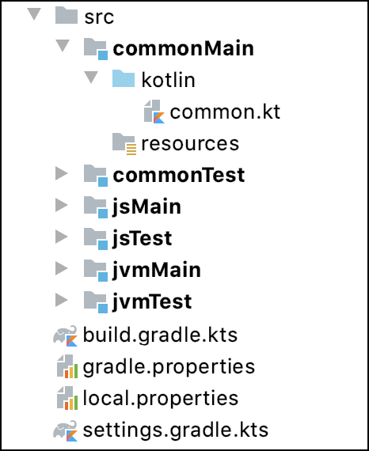

> Source set names are case sensitive.

Source sets are added to the `sourceSets` block of the top-level `kotlin` block.

```
kotlin {
    sourceSets {
        commonMain { /* ... */}
        commonTest { /* ... */}
        jvmMain { /* ... */}
        jvmTest { /* ... */ }
        jsMain { /* ... */}
        jsTest { /* ... */}
    }
}
```

```
kotlin {
    sourceSets {
        val commonMain by getting { /* ... */ }
        val commonTest by getting { /* ... */ }
        val jvmMain by getting { /* ... */ }
        val jvmTest by getting { /* ... */ }
        val jsMain by getting { /* ... */ }
        val jsTest by getting { /* ... */ }
    }
}
```

Source sets form a hierarchy, which is used for sharing the common code. In a source set shared among several targets, you can use the platform-specific language features and dependencies that are available for all these targets.

For example, all Kotlin/Native features are available in the `desktopMain` source set, which targets the Linux (`linuxX64`), Windows (`mingwX64`), and macOS (`macosX64`) platforms.

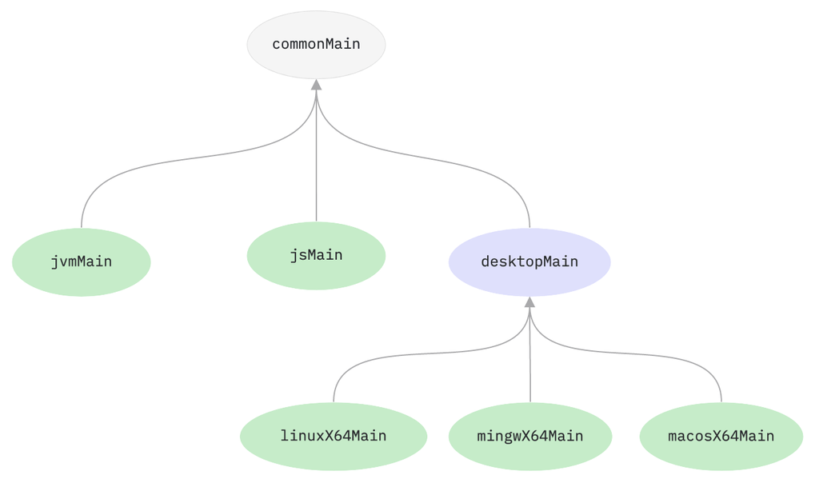

Learn how to build the hierarchy of source sets.

## Compilations

Each target can have one or more compilations, for example, for production and test purposes.

For each target, default compilations include:

- `main` and `test` compilations for JVM, JS, and Native targets.
- A compilation per [Android build variant](https://developer.android.com/studio/build/build-variants), for Android targets.

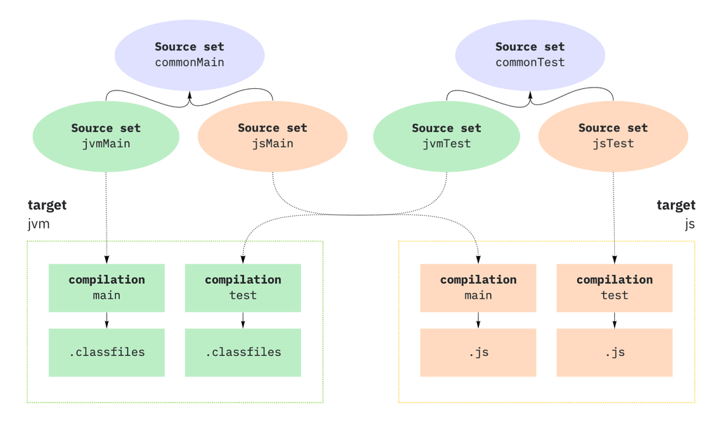

Learn how to configure compilations.

© 2010–2020 JetBrains s.r.o. and Kotlin Programming Language contributors  
Licensed under the Apache License, Version 2.0.  
https://kotlinlang.org/docs/reference/mpp-discover-project.html